# Taller de Redes 2

# Taller Práctico

Utilizaremos un dataset que contiene los proyectos de ley presentados por diputados durante el año 2006. Cada nodo representa una persona y los arcos el boletín (proyecto) presentado por ambos. Para ello, cargaremos los datasets `netsponsor_2006_1mes.csv` y `vertex_2006_1mes.csv`.

```r
edgesponsor <- read.csv("data/netsponsor_2006_1mes.csv", sep = ";")
vertexsponsor <- read.csv("data/vertex_2006_1mes.csv", sep = ";")
```

Luego transformamos ambos dataset a un grafo.

```r
netsponsor <- graph_from_data_frame(d = edgesponsor, vertices = vertexsponsor, directed = F)
```

E inspeccionamos los nodos y arcos.

```r
V(netsponsor)
```

```
## + 65/65 vertices, named, from 6be3401:
##  [1] 2   3   7   8   10  11  12  14  15  16  17  18  20  21  22  23  24
## [18] 25  26  29  30  34  35  38  39  41  43  44  47  50  51  52  54  58
## [35] 62  64  65  66  68  69  71  72  75  76  81  82  83  84  85  88  92
## [52] 95  96  97  99  102 106 108 109 110 113 116 118 119 120
```

```r
E(netsponsor)
```

```
## + 634/634 edges from 6be3401 (vertex names):
##  [1] 8 --82  12--24  3 --34  22--41  2 --21  14--15  7 --10  12--51
##  [9] 12--41  12--41  24--35  41--50  2 --21  3 --18  7 --24  16--23
## [17] 7 --24  7 --17  16--21  43--47  15--41  11--17  21--92  12--29
## [25] 3 --71  22--50  2 --44  14--26  7 --12  12--62  12--51  12--51
## [33] 24--58  41--58  2 --92  3 --20  7 --41  16--39  7 --41  7 --24
## [41] 16--24  43--52  15--43  11--30  21--110 12--39  3 --83  22--51
## [49] 2 --64  14--43  7 --16  12--76  12--62  12--62  24--116 41--72
## [57] 3 --25  7 --43  16--41  7 --43  7 --41  16--41  43--68  15--69
## [65] 11--95  2 --21  12--41  22--64  2 --84  14--44  7 --41  12--96
## [73] 12--75  12--75  41--75  3 --38  7 --44  16--51  7 --44  7 --44
## + ... omitted several edges
```

Así como también sus atributos

```r
edge_attr(netsponsor)
```

```
## $idboletin
##   [1] 4140 4139 4137 4133 4132 4130 4124 4123 4122 4121 4120 4117 4116 4114
##  [15] 4112 4111 4110 4109 4142 4141 4138 4125 4115 4139 4137 4133 4132 4130
##  [29] 4124 4123 4122 4121 4120 4117 4116 4114 4112 4111 4110 4109 4142 4141
##  [43] 4138 4125 4115 4139 4137 4133 4132 4130 4124 4123 4122 4121 4120 4117
##  [57] 4114 4112 4111 4110 4109 4142 4141 4138 4125 4115 4139 4133 4132 4130
##  [71] 4124 4123 4122 4121 4117 4114 4112 4111 4110 4109 4142 4138 4125 4139
##  [85] 4133 4132 4130 4124 4123 4122 4121 4117 4114 4112 4111 4110 4109 4142
##  [99] 4139 4133 4132 4130 4124 4123 4122 4121 4114 4112 4111 4110 4109 4142
## [113] 4139 4133 4132 4130 4124 4122 4121 4114 4112 4111 4110 4109 4142 4139
## [127] 4133 4132 4130 4124 4122 4121 4112 4111 4110 4109 4142 4139 4133 4132
## [141] 4130 4124 4112 4111 4110 4109 4142 4139 4137 4133 4132 4130 4124 4123
## [155] 4122 4121 4120 4117 4116 4114 4112 4111 4110 4109 4142 4141 4138 4125
## [169] 4115 4139 4137 4133 4132 4130 4124 4123 4122 4121 4120 4117 4114 4112
## [183] 4111 4110 4109 4142 4141 4138 4125 4115 4139 4133 4132 4130 4124 4123
```

[output cut: 161 more lines]

```r
vertex_attr(netsponsor)
```

```
## $name
##  [1] "2"   "3"   "7"   "8"   "10"  "11"  "12"  "14"  "15"  "16"  "17"
## [12] "18"  "20"  "21"  "22"  "23"  "24"  "25"  "26"  "29"  "30"  "34"
## [23] "35"  "38"  "39"  "41"  "43"  "44"  "47"  "50"  "51"  "52"  "54"
## [34] "58"  "62"  "64"  "65"  "66"  "68"  "69"  "71"  "72"  "75"  "76"
## [45] "81"  "82"  "83"  "84"  "85"  "88"  "92"  "95"  "96"  "97"  "99"
## [56] "102" "106" "108" "109" "110" "113" "116" "118" "119" "120"
##
## $full_name
##  [1] "Aedo OrmeÃ±o, RenÃ©"
##  [2] "AguilÃ³ Melo, Sergio"
##  [3] "Ã\201lvarez Zenteno, Rodrigo"
##  [4] "Alvarez-Salamanca BÃ¼chi, Pedro Pablo"
##  [5] "Arenas HÃ¶dar, Gonzalo"
##  [6] "Ascencio Mansilla, Gabriel"
```

[output cut: 154 more lines]

Primero, visualizaremos el grafo sin mayor procesamiento ya que solo quitaremos los labels de los nodos y ajustaremos el tamaño del vértice y arco.

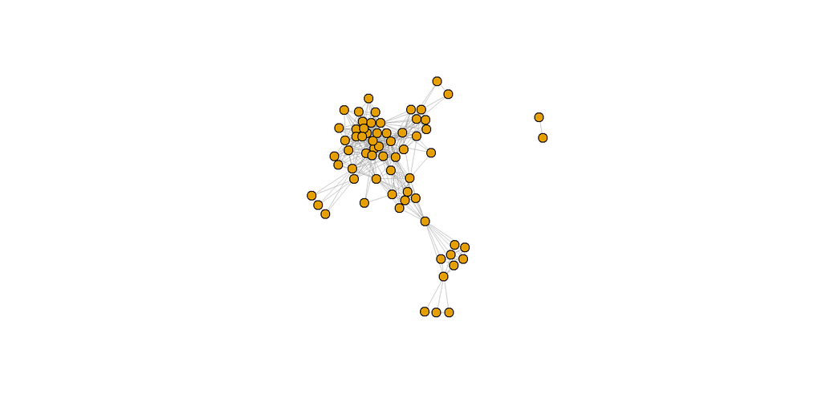

```r
lay <- layout_with_fr(netsponsor)
plot(netsponsor, vertex.label = NA, vertex.size = 8, edge.width = 0.5, layout = lay)
```

Dado que tenemos tres tipos de pactos, asignaremos colores a cada uno de estos para visualizarlos en el grafo.

```r
coal_colors <- length(V(netsponsor)$pact)
coal_colors [V(netsponsor)$pact == "Alianza"] <- "royalblue4"
coal_colors [V(netsponsor)$pact == "Concertacion/NM"] <- "darkred"
coal_colors [V(netsponsor)$pact == "Otro"] <- "yellow2"
```

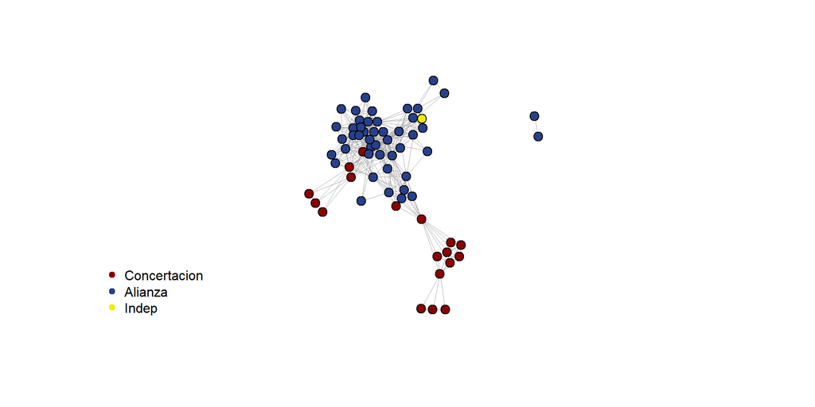

```r
plot(netsponsor, vertex.label = NA, vertex.size = 8, edge.width = 0.5, vertex.color = coal_colors, layout = lay)

legend("bottomright",
       legend = c("Concertacion", "Alianza", "Indep"),
       col = c("darkred", "royalblue4", "yellow2" ),
       pch = 20,
       bty = "n",
       pt.cex = 1.5,
       cex = 1,
       text.col = "black",
       horiz = F ,
       inset = c(.8, 0))
```

Al igual que en el dataset anterior, estimaremos el clique de la red.

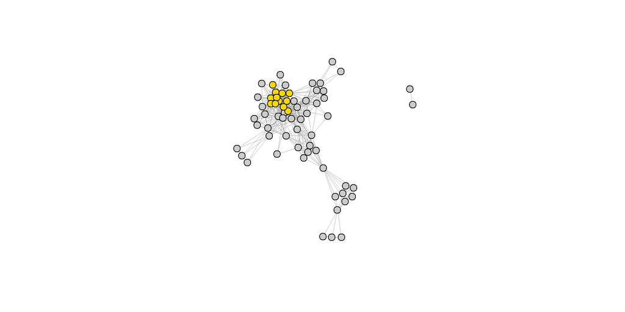

```r
cl.ns <- largest_cliques(netsponsor)
vcol <- rep("grey80", vcount(netsponsor))
vcol[unlist(largest_cliques(netsponsor))] <- "gold"
plot(as.undirected(netsponsor), vertex.label=NA, vertex.color=vcol, vertex.size = 8, edge.width = 0.5, layout = lay)
```

Adicionalmente, ya que no podemos colorear los pactos dado que lo estamos haciendo para el clique, agregaremos `shapes` a cada uno.

```r
source("data/triangle_shape.R") #triangulos no estan como figuras asi que lo agregaremos nosotros
coal_shapes <- length(V(netsponsor)$pact)
coal_shapes [V(netsponsor)$pact == "Alianza"] <- "circle"
coal_shapes [V(netsponsor)$pact == "Concertacion/NM"] <- "triangle"
coal_shapes [V(netsponsor)$pact == "Otro"] <- "square"
```

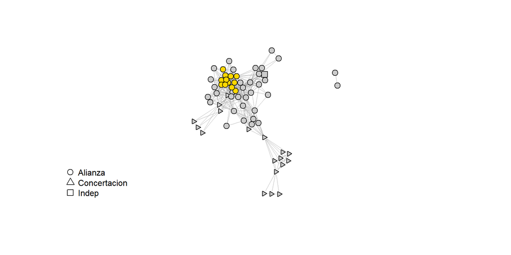

```r
vcol <- rep("grey80", vcount(netsponsor))
vcol[unlist(largest_cliques(netsponsor))] <- "gold"
plot(netsponsor, vertex.label=NA, vertex.color=vcol, vertex.size = 8, edge.width = 0.5, layout = lay, vertex.shape = coal_shapes)

legend("bottomright",
       legend = c("Alianza", "Concertacion", "Indep"),
       pch = c(1,2,0),
       bty = "n",
       pt.cex = 1.5,
       cex = 1,
       text.col = "black",
       horiz = F ,
       inset = c(.8, 0))
```

También podemos obtener las comunidades que se generan a partir del principal utilizando el algoritmo de **Newman-Girvan**.

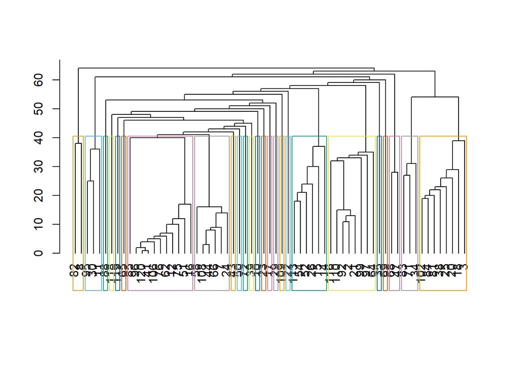

```r
ceb.ns <- cluster_edge_betweenness(netsponsor)
dendPlot(ceb.ns, mode="hclust")
```

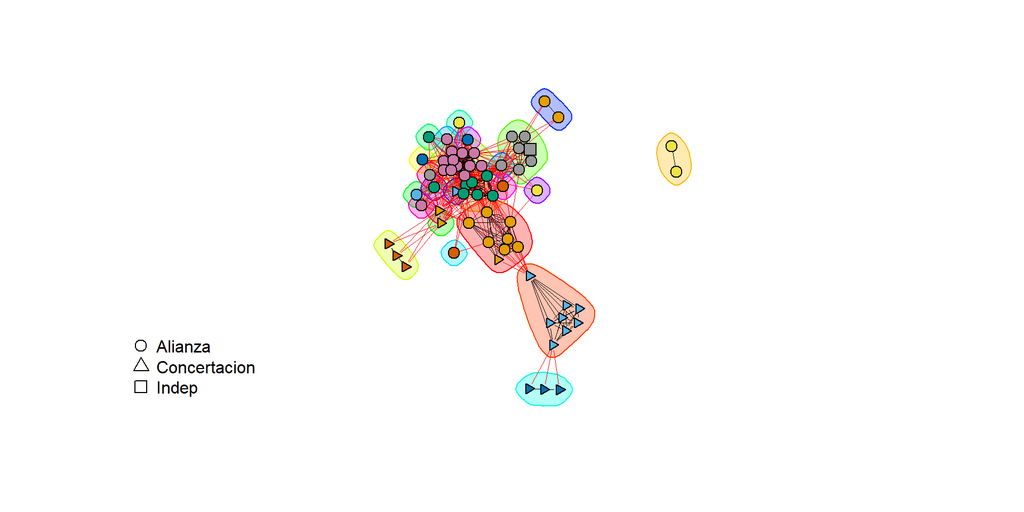

```r
plot(ceb.ns, netsponsor, vertex.label=NA, vertex.color=vcol, vertex.size = 8, edge.width = 0.5, layout = lay, vertex.shape = coal_shapes)

legend("bottomright",
       legend = c("Alianza", "Concertacion", "Indep"),
       pch = c(1,2,0),
       bty = "n",
       pt.cex = 1.5,
       cex = 1,
       text.col = "black",
       horiz = F ,
       inset = c(.8, 0))
```

Para terminar, calcularemos algunas medidas analíticas de la red, como su distancia promedio y su diámetro:

```r
mean_distance(netsponsor)
```

```
## [1] 2.262027
```

```r
diam <- get_diameter(netsponsor)
diam
```

```
## + 6/65 vertices, named, from 6be3401:
## [1] 10 7  44 84 3  34
```

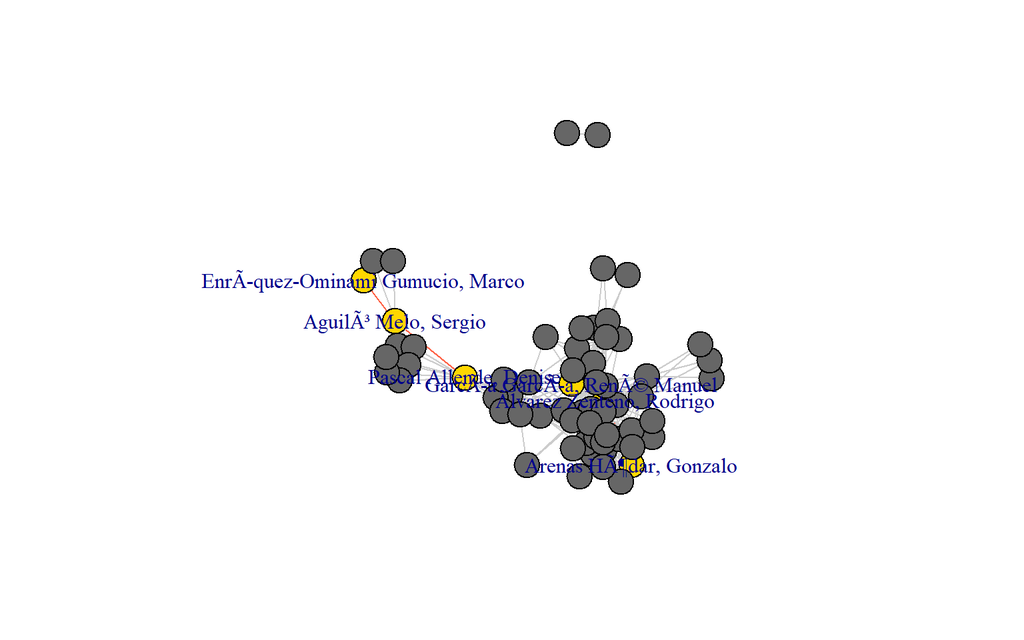

```r
vcol <- rep("gray40", vcount(netsponsor))

vcol[diam] <- "gold" # Pintamos dorados los nodos del diámetro

ecol <- rep("gray80", ecount(netsponsor))

ecol[E(netsponsor, path=diam)] <- "tomato" # Pintamos rojos los arcos del diámetro

plot(netsponsor, vertex.color=vcol, edge.color=ecol, vertex.label=ifelse(V(netsponsor)$name %in% V(netsponsor)[diam]$name, V(netsponsor)$full_name, NA), edge.arrow.size=0.5)
```

Finalmente, obtendremos los nombres de quienes son más importantes para la red, calculando las medidas de centralidad

```r
deg <- degree(netsponsor, mode="total")
amax <- which(deg==max(deg))
V(netsponsor)[amax]$full_name
```

```
## [1] "Forni Lobos, Marcelo"
```

```r
max(deg)
```

```
## [1] 97
```

```r
# La cercanía no está definida en redes desconectadas, entonces obtenemos la componente más grande

clo <- closeness(induced.subgraph(netsponsor, V(netsponsor)[components(netsponsor)$membership==1]))
amax <- which(clo==max(clo))
V(netsponsor)[amax]$full_name
```

```
## [1] "Galilea Carrillo, Pablo"
```

```r
max(clo)
```

```
## [1] 0.01020408
```

```r
bet <- betweenness(netsponsor)
amax <- which(bet==max(bet))
V(netsponsor)[amax]$full_name
```

```
## [1] "Pascal Allende, Denise"
```

```r
max(bet)
```

```
## [1] 520
```